# Fundamentos de Sistemas de Bancos de Dados

#### 24/02/2026

## Parte I — Linha do Tempo dos SGBDs

### O Início do Modelo Relacional

### Edgar F. Codd (1923–2003)

[figure not shown]

- Matemático da IBM
- 1970: Publica o artigo:

> **“A Relational Model of Data for Large Shared Data Banks”** (Um modelo relacional de dados para grandes bancos de dados compartilhados)

Base matemática do modelo:

- Teoria dos Conjuntos
- Lógica de Predicados
- Álgebra Relacional

### System R e SQL

- 1970–1974: Desenvolvimento do **System R**
- 1974: Criação da linguagem **SQL**

### Raymond F. Boyce

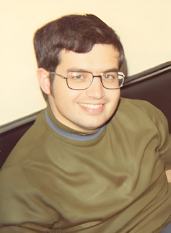

### Modelo Entidade-Relacionamento

### Peter Chen

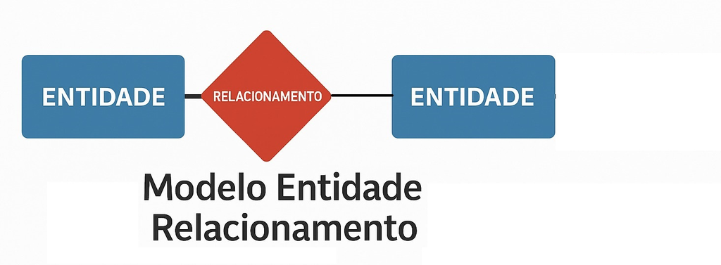

- 1976: Modelo ER
- Ponte entre modelagem conceitual e implementação relacional

### Prof Michael Stonebraker

[figure not shown]

- Projeto INGRES
- Origem do Postgres

### Décadas de Consolidação

#### 1980

- IBM DB2
- Oracle
- Sybase
- Postgres

#### 1990

- PostgreSQL
- MySQL

[figure not shown]

[figure not shown]

### Anos 2000 — Big Data e NoSQL

[figure not shown]

[figure not shown]

[figure not shown]

## Parte II — Fundamentos Matemáticos do Modelo Relacional

Agora entramos na base formal que sustenta os SGBDs.

## 1. Conceito de Relação

Codd queria utilizar a Matemática, mais específicamente, a teoria de conjuntos para criar um Sistema de Banco de Dados. A Matemática trataria de garantir a consistência dos dados armazenados.

| Operação | Símbolo | Descrição |
| --- | --- | --- |
| União | ∪ | Elementos que pertencem a A ou B |
| Interseção | ∩ | Elementos comuns a A e B |
| Diferença | − | Elementos de A que não pertencem a B |
| Produto Cartesiano | × | Conjunto de todos os pares ordenados (a,b) |

Inicialmente a idéia era associar conjuntos de dados e garantir a consistência da informação. Assim nasceu o conceito de **RELAÇÃO**

Sejam dois conjuntos A e B.

O **produto cartesiano** é:

```
A × B = { (a,b) | a ∈ A e b ∈ B }
```

Uma **relação R de A em B** é qualquer subconjunto de A × B.

```
R ⊆ A × B
```

*(lembrando que o simbolo “⊆” significa “está contido em” ou “é subconjunto de”)*

#### Exemplo 1.

Uma website vende camisetas **básicas** e camisetas **esportivas** nos tamanhos **pequeno**, **médio** e **grande**. Usando matemática, coloque as camisetas no **conjunto A** e os tamanhos no **conjunto B**. Utilize o **produto cartesiano** para gerar toda a **grade de camisetas e tamanhos** na página do website.

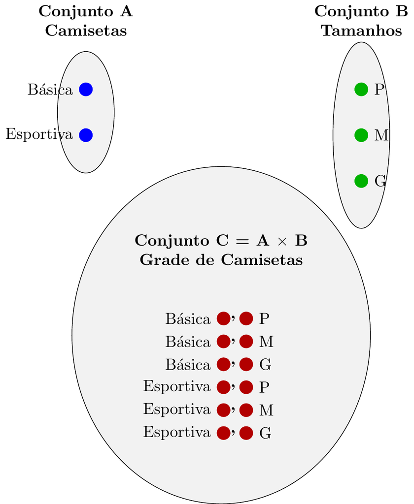

Camisetas X Tamanhos

No exemplo anterior, o conjunto C foi criado fazendo produto cartesiano de A x B. O **conjunto C** é uma **Relação.**

Contudo as operações da teoria dos conjuntos da matemática não eram suficientes para resolver algumas situações:

#### Exemplo 2.

Considere uma **cadastro de países** denominado **conjunto A = {Brasil, Argentina, Chile }** e um **cadastro de capitais** chamado **conjunto B = {Brasilia, Buenos Aires, Santiago}**. `Verifique se é possível` criar um **conjunto C** utilizando o **produto cartesiano** entre **A x B**, ou seja, uma **Relação**. Nesta **relação C**, **`cada país deve estar associado a sua capital`**.

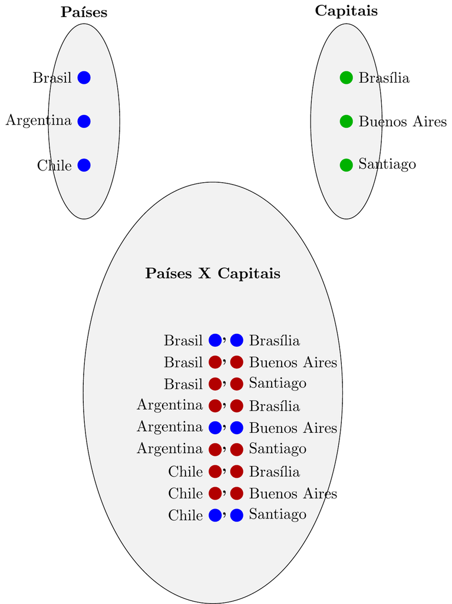

Capital X Países

Verificando a operação de **produto cartesiano** que gerou o **conjunto C** produziu **9 pares ordenados**. Mas para nosso contexto (**associar países e suas capitais**) dos **9 pares** gerados, apenas **`3 pares ordenados fazem sentido`**: C= {(**Brasil, Brasilia**), (**Argentina, Buenos Aires**), (**Chile, Santiago**)} ; os outros **6 pares não fazem sentido** na associação de Países e Capitais.

Portanto, para este contexto, apenas a operação de produto cartesiano não atendeu os requisitos para gerar um conjunto de dados consistente a partir de dois cadastros (dois conjuntos) fornecidos.

### A Solução vem da Matemática: FUNÇÕES como RELACIONAMENTOS:

Uma **função** é uma relação especial entre dois conjuntos.

Sejam ( A ) e ( B ) conjuntos.

Uma função

$f: A \to B$

é um subconjunto do produto cartesiano

$f \subseteq A \times B$

em bom português: >> Uma função f(x) é uma regra que associa cada elemento de A a exatamente um elemento de B.

As funções f(x) agem como uma filtragem para selecionar do produto cartesiano apenas os pares de elementos que fazem sentido:

As funções podem ser vistas como setas mapeando cada ponto de um conjunto no outro.

No exemplo da loja de camisetas, temos cada elemento do “conjunto A” mapeando todos os elementos do “conjunto B”. É a representação gráfica do produto cartesiano e seus pares ordenados.

[figure not shown]

camisetas X Tamanhos

No exemplo dos países e suas capitais, temos um elemento do “conjunto A” mapeando um elemento do “conjunto B”. É um subconjunto do produto cartesiano de A X B, ou seja, uma filtragem aplicada ao produto cartesiano. Na terminologia das funções, é uma função bijetora.

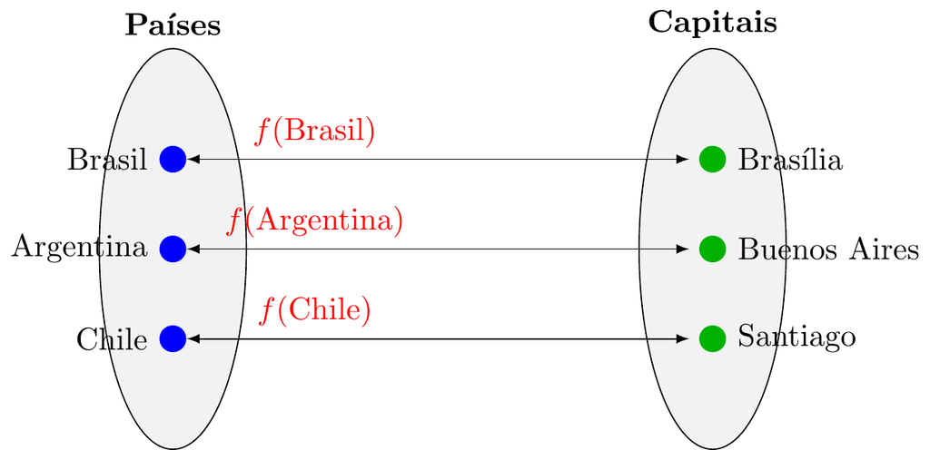

Países X Capitais

Conclusão de Codd: apenas as operações convencionais da teoria de conjuntos não seria suficiente para projetar sistema de banco de dados. Seria necessária a adição de elementos teoria das funções aplicada a teoria das relações.

Professor Codd cria as operações de Algebra Relacional associada a Relações.

Nasce o conceito de Banco de Dados Relacional e os conceitos que irão criar a linguagem SQL (Structured Query Language).

### Relação em Banco de Dados

Considere:

| Terminologia Relacional | Banco de Dados | Origem Matemática |
| --- | --- | --- |
| RELAÇÃO | **TABELA** | CONJUNTO ou SUBCONJUNTO |
| ATRIBUTO | **COLUNAS** | Não aparece explicitamente |
| TUPLA | **LINHA** | ELEMENTO DO CONJUNTO OU PAR ORDENADO |

## 2. Operações Relacionais

Baseadas na Álgebra Relacional de Codd.

| Operação | Símbolo | Descrição |
| --- | --- | --- |
| Seleção | σ | Filtra linhas |
| Projeção | π | Seleciona colunas |
| União | ∪ | Combina relações compatíveis |
| Interseção | ∩ | Elementos comuns |
| Diferença | − | Subtração |
| Produto Cartesiano | × | Combinação total |
| Junção | ⋈ | Produto + Seleção |
| Divisão | ÷ | Consulta universal |

Todas as operações Relacionais são operações SQL e serão estudadas na aula 4 (Modelagem parte 2).

## 3. Propriedades de Relações

Seja R ⊆ A × A.

### 3.1 Reflexiva

“Todo elemento é equivalente a si mesmo”

```
∀x ∈ A, (x,x) ∈ R
```

Exemplo: Em um cadastro de produtos, o produto Teclado tem a mesma categoria que o produto Teclado (ele mesmo). Consequentemente, em uma tabela do Banco de Dados, o valor da coluna “CategoriaID” de um registro é sempre igual ao “CategoriaID” dele mesmo.

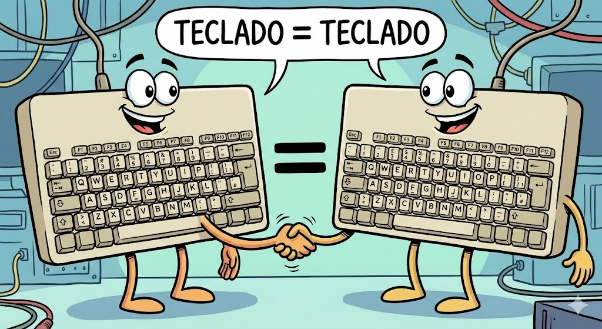

### 3.2 Simétrica

“Se o **primeiro equivale ao segundo**, então o **segundo equivale ao primeiro**”

```
Se (x,y) ∈ R então (y,x) ∈ R
```

Exemplo: Se o **Teclado** (1) **é equivalente** ao **Mouse** (2) (ambos são da categoria **Eletrônicos**), então o **Mouse** (2) **é equivalente** ao **Teclado** (1). Consequentemente, no Banco de Dados, **Teclado.CategoriaID** = **Mouse.CategoriaID.**

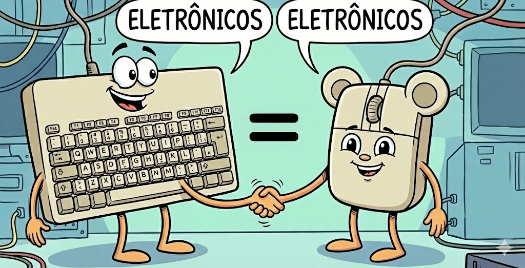

Essa propriedade é utilizada para fazer “pareamento” entre tabelas.

### 3.3 Transitiva

“Se o **primeiro equivale ao segundo**, e o **segundo equivale ao terceiro**”, então **primeiro equivale ao terceiro.”**

```
Se (x,y) ∈ R e (y,z) ∈ R então (x,z) ∈ R
```

Exemplo: Se **Teclado** (1) **é equivalente** ao **Mouse** (2) e **Mouse** (2) **é equivalente** ao **Monitor** (3), então obrigatoriamente **Teclado** (1) **é equivalente** ao **Monitor** (3), **pois todos são da categoria “Eletrônicos”**.

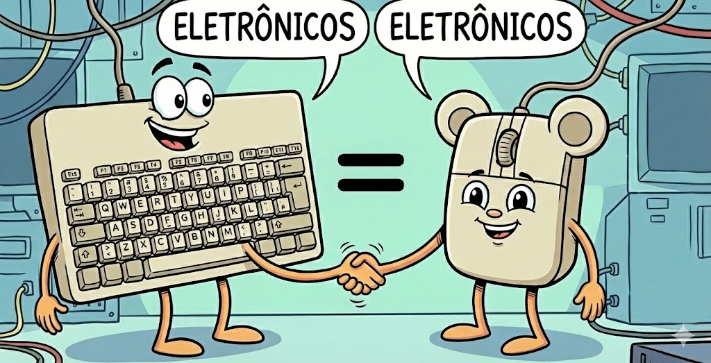

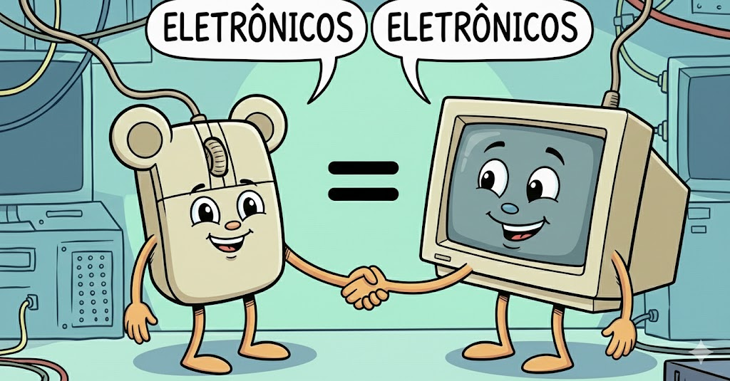

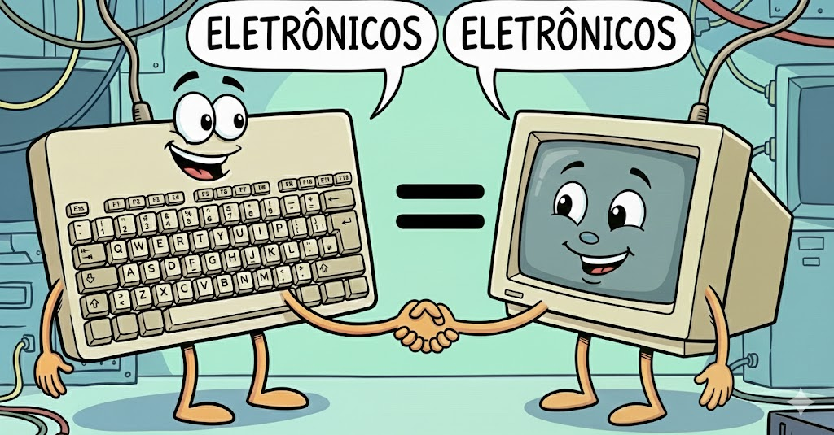

Isso garante que todos os elementos de uma categoria formem um grupo fechado e coeso.

### 3.4 Antissimétrica

“Se o **primeiro equivale ao segundo**, então o **segundo NÃO PODE equivaler ao primeiro**”

```
Se (x,y) ∈ R e (y,x) ∈ R então x = y
```

Exemplo: Se o **João é gerente da Maria**, a **Maria NÃO PODE ser gerente do João**. Em uma tabela de funcionários, o Banco de dados garante HIERARQUIA na regra de negócio.

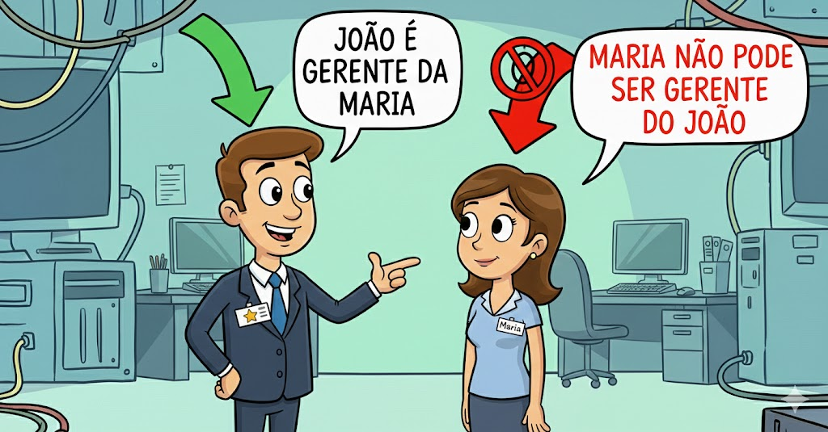

## 4. Relação de Equivalência

Uma relação é de equivalência se é:

- Reflexiva
- Simétrica
- Transitiva

Exemplo: Tenho uma tabela de produtos. Todos os produtos estão classificados em categorias. Prove nesta tabela que 2 produtos são equivalentes.

| **ID (Elemento)** | **Nome do Produto** | **CategoriaID (Classe)** |
| --- | --- | --- |
| 1 | Teclado | 1 (Eletrônicos) |
| 2 | Mouse | 1 (Eletrônicos) |
| 3 | Monitor | 1 (Eletrônicos) |
| 4 | Camisa | 2 (Vestuário) |
| 5 | Calça | 2 (Vestuário) |
| 6 | Tênis | 2 (Vestuário) |
| 7 | Livro SQL | 3 (Livraria) |
| 8 | Livro Java | 3 (Livraria) |
| 9 | Livro Redes | 3 (Livraria) |
| 10 | Cadeira | 4 (Móveis) |
| 11 | Mesa | 4 (Móveis) |
| 12 | Sofá | 4 (Móveis) |

Resolução:

“Dois produtos são equivalentes se pertencerem à mesma categoria.”

“Dois produtos não são equivalentes se pertencerem a categorias diferentes.”

Para provar isso, é preciso testar as 3 propriedades de relações (Reflexiva, Simétrica e Transitiva) em relação ao ponto comum entre eles, que é no caso “categoria”.

Tomarei como exemplo “Cadeira, Mesa, Sofá”. Analisarei segundo a caracteristica comum “categoria”:

1. - Reflexiva - Cadeira é da mesma categoria que cadeira ? Sim - OK
2. - Simétrica - Cadeira é da mesma categoria que mesa e Mesa é da mesma categoria que Cadeira ? Sim - OK
3. - Transitiva - Cadeira é da mesma categoria que mesa; Mesa é da mesma categira que sofá; portanto cadeira é da mesma categoria que sofá ? Sim - OK

Considerando que cadeira, mesa e sofá atendem as propriedades “Reflexiva”, “Simétrica” e “Transitiva”, então “Cadeira, Mesa, Sofá” constituem a mesma classe de equivalencia.

### Classes de Equivalência

Dada relação ~ em A:

A classe de equivalência de x é:

```
[x] = { y ∈ A | y ~ x }
```

Exemplo em Banco de Dados:

Relação:

```
x ~ y  ⟺  x mod 3 = y mod 3
```

Classes:

- [0] = {0,3,6,9,…}
- [1] = {1,4,7,…}
- [2] = {2,5,8,…}

### Relações de Equivalência e Normalização

Dependências funcionais induzem partições do conjunto de tuplas.

Quando:

```
A → B
```

Significa que valores iguais de A geram classes de equivalência nas tuplas.

## 5. Conceito de Fecho

Dado conjunto de atributos X e conjunto de dependências funcionais F:

O **fecho de X** (X⁺) é o conjunto de todos os atributos funcionalmente determinados por X.

Exemplo:

Dependências:

```
A → B
B → C
```

Então:

```
A⁺ = {A, B, C}
```

## 6. Normalização

Processo de organização de relações para:

- Eliminar redundância
- Evitar anomalias
- Garantir consistência

### 1ª Forma Normal (1FN)

- Atributos atômicos
- Sem grupos repetitivos

### 2ª Forma Normal (2FN)

- 1FN
- Sem dependência parcial de chave composta

### 3ª Forma Normal (3FN)

- 2FN
- Sem dependência transitiva

### BCNF

Forma mais forte que 3FN:

Para toda dependência:

```
X → Y
```

X deve ser superchave.

## Conexão Final — A Base Matemática do SGBD

| Conceito Matemático | Aplicação em BD |
| --- | --- |
| Relação | Tabela |
| Produto cartesiano | Combinação de domínios |
| Relação de equivalência | Particionamento por chave |
| Fecho | Descoberta de dependências |
| Transitiva | Análise de dependências |
| Antissimétrica | Ordem parcial |
| Álgebra relacional | SQL |